# CMSC 320- Final Tutorial

Dipisha Singh

# Get the story behind Olympics Medal

[figure not shown]

## Introduction

This tutorial will introduce the entire datascience pipeline from data curation, parsing, and management to exploratory data analysis to hypothesis testing and machine learning.The data taken for this tutorial is from [Olympics Medal list of 2016](https://raw.githubusercontent.com/nbremer/olympicfeathers/gh-pages/data/raw%20medal%20data/Rio%202016%20gold%20medal%20winners.txt).The motive to choose this data is to find out the dependencies of medals; for instance, winning medals in olympics can give information about the country’s strong and popular sport. It can also give the range of victory in Olympics based on gender, events, record type.

Sports has been medium of international co-operation and the platform where one can represent the country. Olympics is an international multi-sport event and 206 nations participated in Olympics 2016. There are always economic as well as prestigious benefits for the country on winning the medals. With the data and its analysis, businesses try to get grips for the players with the potetial to win in the next olympic. Therefore, olympics data analysis is necessary for comparison as well as response enactment for better outcome in future.

## Overview and Content

In this tutorial, we will demonstrate

1. Procurement of olympic medals’ data via R.
2. Plotting of several variables and visualization of relationships between medals and other variables
3. Implementation of hypotheis testing and machine learning through t-statistic and linear regression

## Libraries Used

The libraries used in this project and the links from were I took reference are listed below:

- [dplyr](http://genomicsclass.github.io/book/pages/dplyr_tutorial.html)
- [tidyverse](https://www.tidyverse.org/)
- [broom](https://cran.r-project.org/web/packages/broom/vignettes/broom.html)
- [tree](https://cran.r-project.org/web/packages/data.tree/vignettes/data.tree.html)
- [plotrix](https://rdrr.io/cran/plotrix/man/pie3D.html)
- ggplot2
- [stringr](https://cran.r-project.org/web/packages/stringr/vignettes/stringr.html)

## Data Curation and Parsing

Data Curation is an important step during the data analysis process. It provides meaningful access to the data.It involves constructing a structure that sorts the data into a meaningful retrieval system and gives us intellectual control over content.

In this tutorial, We will use lot of functions from deifferent libraries as well as we will write function as per the necessity to decrease redundancy of code. We will create, scrape and parse the given file from the url and make a dataframe for further analyis

### Importing the libraries and reading table from url

```r
library(dplyr)
library(tidyr)
library(tidyverse)
library(stringr)
library(ggplot2)
library(plotrix)
library(tree)
library(broom)

# Reading the url
url <- "https://raw.githubusercontent.com/nbremer/olympicfeathers/gh-pages/data/raw%20medal%20data/Rio%202016%20gold%20medal%20winners.txt"
olympics <- read.table(url, sep = "\t", header = TRUE, na.strings = "",
                       stringsAsFactors = FALSE)

# Giving column names
colnames(olympics) <- c("Athlete_Name", "Country", "Country_Code" , "Gender" , "Sport" , "Discipline" , "Event", "Event_Gender" , "Record" , "Record_Type")

as_data_frame(olympics)
```

```
## # A tibble: 312 x 10
##    Athlete_Name  Country     Country_Code Gender Sport Discipline Event
##    <chr>         <chr>       <chr>        <chr>  <chr> <chr>      <chr>
##  1 Ren Qian      China       CHN          Women  Aqua~ Diving     10m Pla~
##  2 Aisen Chen    China       CHN          Men    Aqua~ Diving     10m Pla~
##  3 Yuan Cao      China       CHN          Men    Aqua~ Diving     3m Spri~
##  4 Tingmao Shi   China       CHN          Women  Aqua~ Diving     3m Spri~
##  5 <NA>          China       CHN          Women  Aqua~ Diving     Synchro~
##  6 <NA>          China       CHN          Men    Aqua~ Diving     Synchro~
##  7 <NA>          Great Brit~ GBR          Men    Aqua~ Diving     Synchro~
##  8 <NA>          China       CHN          Women  Aqua~ Diving     Synchro~
##  9 Anthony Ervin United Sta~ USA          Men    Aqua~ Swimming   50m Fre~
## 10 Katinka Hoss~ Hungary     HUN          Women  Aqua~ Swimming   100m Ba~
## # ... with 302 more rows, and 3 more variables: Event_Gender <chr>,
## #   Record <chr>, Record_Type <chr>
```

### Tidying the data

This section includes data preparation, that is taking raw datasets and make changes to turn messy data into tidy data. If we open the url and see the table, we can observe that there are lots of things that can be made simple. For instance, we can drop the gender column as Gender and Event_gender column has the same thing except Gender has women and men and Event_gender has M ad W as symbols. After dropping we will then rename Event_gender as Gender.On the other hand, it can be observed that Records and Record_Type are mostly NA. As other columns have important information, it is not good to just eliminate athletes with NA record. SO, I have combined Record and record Type as records.

### replace_na_new function

While tidying data, below we will see replace_na_new function which is written to replace any text or number for any columns haing NA.

```r
# Removing Gender and renaming Event_Gender as Gender
tidy_olympics <- subset(olympics, select= -c(Gender))
colnames(tidy_olympics)[colnames(tidy_olympics)== "Event_Gender"] <- "Gender"

# Writing min as m and sec as s in Record column
tidy_olympics$Record <- gsub('min', 'm', tidy_olympics$Record)
tidy_olympics$Record<- gsub('sec', 's', tidy_olympics$Record)

#Writing Yes if record typeis OR(olympic Record)
tidy_olympics$if_OR <-ifelse(tidy_olympics$Record_Type == "OR", "Yes", "No")

# Extracting the name of Event and separating
tidy_olympics$Event_name <- sub("^\\S+\\s+", '', tidy_olympics$Event)
tidy_olympics$Num <- str_extract(tidy_olympics$Event, "[0-9]+")

# replace function which writes the desired string or number for NA
replace_na_new <- function(data, replace = list(), ...){
  stopifnot(rlang::is_list(replace))
  replace <- rlang::modify(replace, ...)
  for (var in names(replace)) {
    data[[var]][rlang::are_na(data[[var]])] <- replace[[var]]
  }
  data
}

# Using above replace function
olympics_sub <- tidy_olympics%>%
  subset(select = -c(Event))%>%
  replace_na_new(Athlete_Name = "Anonymous", Record = 0, Record_Type = "None", Num= 0)%>%
  unite(Records, Record, Record_Type, sep='- ')%>%
  arrange(desc(Country))


as_data_frame(olympics_sub)
```

```
## # A tibble: 312 x 10
##    Athlete_Name Country Country_Code Sport Discipline Gender Records if_OR
##    <chr>        <chr>   <chr>        <chr> <chr>      <chr>  <chr>   <chr>
##  1 Hoang Xuan ~ Vietnam VIE          Shoo~ Shooting   M      Final ~ Yes
##  2 Shakhobidin~ Uzbeki~ UZB          Boxi~ Boxing     M      0- None <NA>
##  3 Hasanboy Du~ Uzbeki~ UZB          Boxi~ Boxing     M      0- None <NA>
##  4 Fazliddin G~ Uzbeki~ UZB          Boxi~ Boxing     M      0- None <NA>
##  5 Ruslan Nuru~ Uzbeki~ UZB          Weig~ Weightlif~ M      0- None <NA>
##  6 Anthony Erv~ United~ USA          Aqua~ Swimming   M      0- None <NA>
##  7 Anonymous    United~ USA          Aqua~ Swimming   M      0- None <NA>
##  8 Lilly King   United~ USA          Aqua~ Swimming   W      1 m 4.~ Yes
##  9 Simone Manu~ United~ USA          Aqua~ Swimming   W      52.70 ~ Yes
## 10 Maya DiRado  United~ USA          Aqua~ Swimming   W      0- None <NA>
## # ... with 302 more rows, and 2 more variables: Event_name <chr>,
## #   Num <chr>
```

## Data Management

Here, we will divide the dataframe into subsets.Getting subsets of olympic_sub which makes it easier for analysis later. We will see the reason in the analysis section. The first one is olympics_data includes specific columns(Country, Sport, Gender, Event_name). Any unnecessary variables are removed. The second dataframe is have _record which includes Country_Code, Sport, Records, if_OR. if_OR gives yes if it is olypic record type and any recordtype, athlete name with NA rows are eliminated in this seocnd dataframe.

```r
# Dropping Country and renaming country_code with country
olympics_data<- olympics_sub %>%
  subset(select = -c(Athlete_Name, Country, Discipline, Records, if_OR, Num))

colnames(olympics_data)[colnames(olympics_data)== "Country_Code"] <- "Country"
as_data_frame(olympics_data)
```

```
## # A tibble: 312 x 4
##    Country Sport         Gender Event_name
##  * <chr>   <chr>         <chr>  <chr>
##  1 VIE     Shooting      M      Air Pistol
##  2 UZB     Boxing        M      (52kg)
##  3 UZB     Boxing        M      Fly (49kg)
##  4 UZB     Boxing        M      Welter (64kg)
##  5 UZB     Weightlifting M      105kg
##  6 USA     Aquatics      M      Freestyle
##  7 USA     Aquatics      M      Freestyle Relay
##  8 USA     Aquatics      W      Breaststroke
##  9 USA     Aquatics      W      Freestyle
## 10 USA     Aquatics      W      Backstroke
## # ... with 302 more rows
```

```r
# filtering out the rows with NA
have_record <- olympics_sub%>%
  filter(Records != "0- None" & Athlete_Name != "Anonymous")%>%
  select(Athlete_Name, Gender, Country_Code, Sport, Records, if_OR)

colnames(have_record)[colnames(have_record)== "Country_Code"] <- "Country"
as_data_frame(have_record)
```

```
## # A tibble: 38 x 6
##    Athlete_Name    Gender Country Sport         Records             if_OR
##    <chr>           <chr>  <chr>   <chr>         <chr>               <chr>
##  1 Hoang Xuan Vinh M      VIE     Shooting      Final 202.5 pts- OR Yes
##  2 Lilly King      W      USA     Aquatics      1 m 4.93 s- OR      Yes
##  3 Simone Manuel   W      USA     Aquatics      52.70 s- OR         Yes
##  4 Katie Ledecky   W      USA     Aquatics      3 m 56.46 s- WR     No
##  5 Ryan Murphy     M      USA     Aquatics      51.85 s- WR         No
##  6 Katie Ledecky   W      USA     Aquatics      8 m 4.79 s- WR      No
##  7 Ashton Eaton    M      USA     Athletics     8893 pts- OR        Yes
##  8 Ryan Crouser    M      USA     Athletics     22.52 m- OR         Yes
##  9 Ginny Thrasher  W      USA     Shooting      Final 208.0 pts- OR Yes
## 10 Yuri Cheban     M      UKR     Canoe / Kayak 39.279 s- OB        No
## # ... with 28 more rows
```

## Exploratory Data Analysis (EDA)

Exploratory Data Analysis helps to better understand the tidy data, and help us make decisions about appropriate statistical or Machine Learning methods, or data transformations.In most of the cases,statistical data modeling is not required to tell a clear and convincing story;an effective visualization can lead to convincing conclusions.

The goal of EDA in this tutorial is to perform an initial exploration of attributes/variables across entities/observations.We will focus on exploration of single or pair of variables. Length function has been very useful to identify the number of medals based on many variables like gender, country, events. Also, Popular games was investigated for all the participating countries. With the top five countries having highest number of medals, it is necessary to analyze the sport that these countries win most medal for.

### Number of Medals won By Gender

This plot uses barplot to give number of medals won by men , women and x gender.Itcan be observed that there is not much difference of wins between men and women.

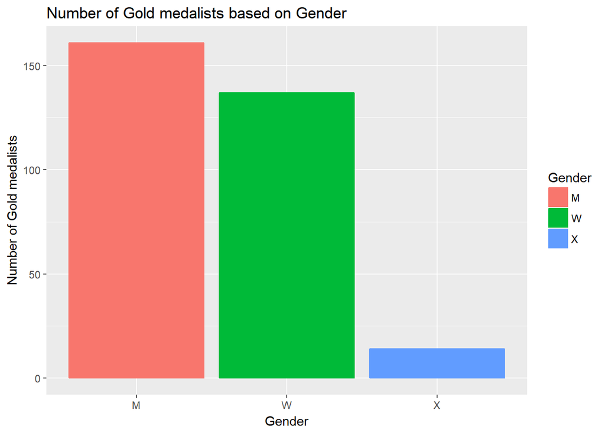

```r
gender_data<- olympics_data%>%
  group_by(Gender)%>%
  summarise(Gender_Count = length(Gender))%>%
  ggplot(aes(x=Gender, y = Gender_Count))+
  geom_bar(stat="identity", mapping = aes(fill= Gender, color=Gender))+
  xlab("Gender") +
  ylab("Number of Gold medalists") +
  ggtitle("Number of Gold medalists based on Gender")
gender_data
```

### Number of Medals Won by Country and its plot

This plot is based on the country and USA has highest wins.

```r
country_count <- olympics_data%>%
  group_by(Country)%>%
  summarise(wins = length(Country))%>%
  arrange(desc(wins))
country_count
```

```
## # A tibble: 59 x 2
##    Country  wins
##    <chr>   <int>
##  1 USA        46
##  2 GBR        28
##  3 CHN        26
##  4 RUS        19
##  5 GER        18
##  6 JPN        12
##  7 FRA        11
##  8 KOR         9
##  9 AUS         8
## 10 HUN         8
## # ... with 49 more rows
```

This is the scatter plot of above data and it can be seen distributed unsymmetrically.The range of wins is mostly below 10.We will check this in next plot.

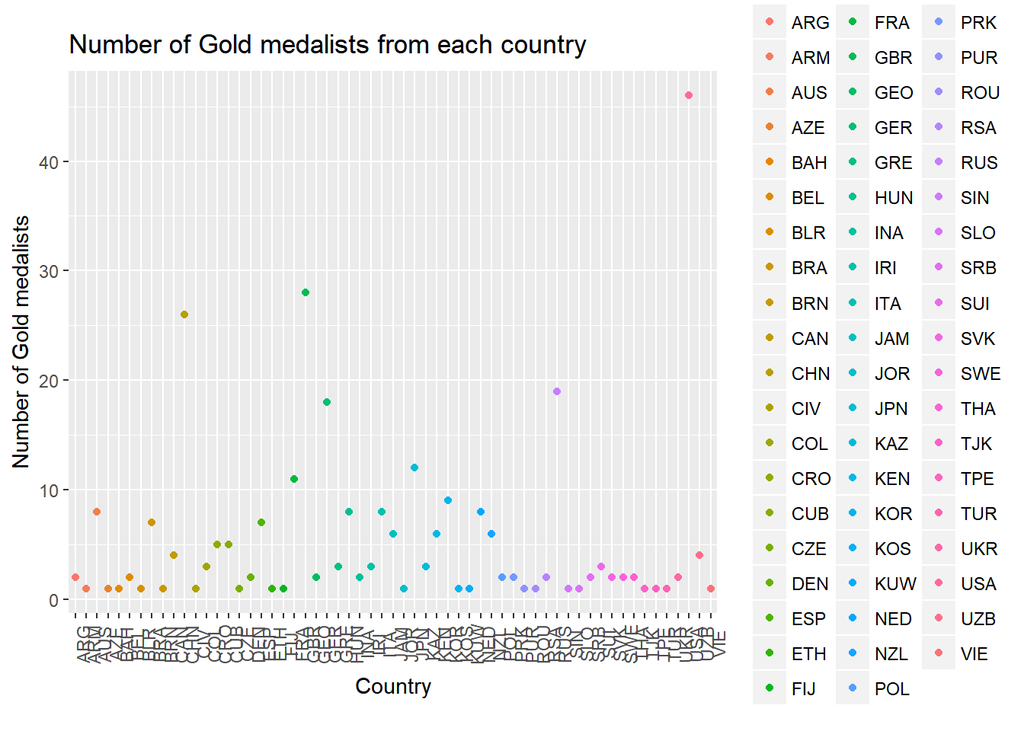

```r
country_count%>%
  ggplot(aes(x=Country, y = wins))+
  geom_point(stat="identity", mapping = aes(fill= Country, color=Country))+
  xlab("Country") +
  ylab("Number of Gold medalists") +
  ggtitle("Number of Gold medalists from each country")+
   theme(axis.text.x = element_text(angle=90, hjust=0.5))+
  coord_fixed()
```

The following plot calculates the mean and it is found that the mean is below 10 that is 5.

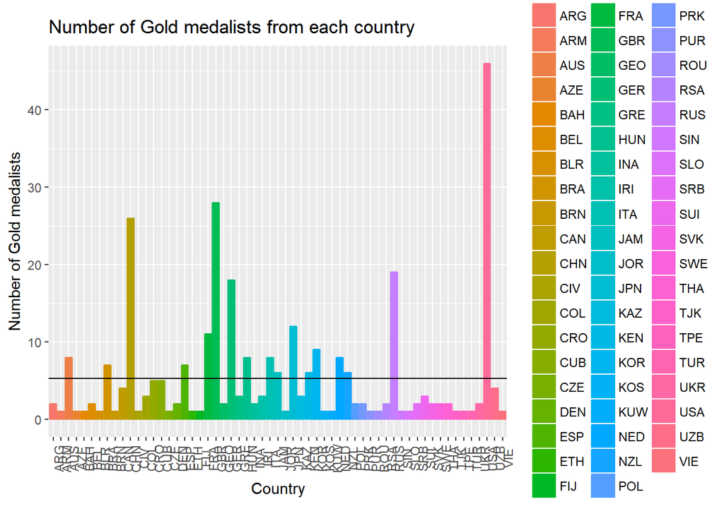

```r
country_count%>%
  ggplot(aes(x=Country, y = wins))+
  geom_histogram(stat="identity", mapping = aes(fill= Country, color=Country))+
  geom_hline(aes(yintercept= mean(wins)))+
  xlab("Country") +
  ylab("Number of Gold medalists") +
  ggtitle("Number of Gold medalists from each country")+
   theme(axis.text.x = element_text(angle=90, hjust=0.5))+
  coord_fixed()
```

### create sd values with plot

We can also use standard deviations as an interpretable unit

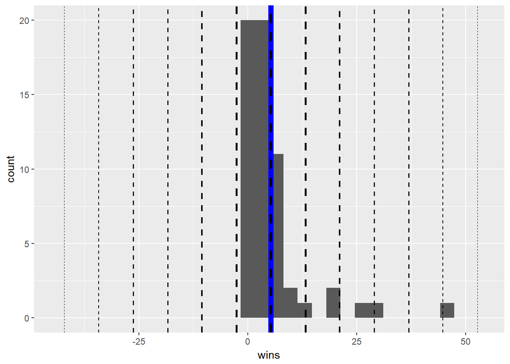

```r
sds_to_plot <- seq(-6,6)
sd_df <- country_count %>%
  summarize(mean_wins = mean(wins), sd_wins = sd(wins)) %>%
  slice(rep_along(sds_to_plot, 1)) %>%
  mutate(sd_to_plot=sds_to_plot) %>%
  mutate(sd_val = mean_wins + sd_to_plot * sd_wins)

country_count %>%
  ggplot(aes(x=wins)) +
    geom_histogram(bins=30) +
    geom_vline(aes(xintercept=mean(wins)), col="blue", size=2.5) +
    geom_vline(aes(xintercept = sd_val), data=sd_df,
               linetype=2, size=1.2 - abs(seq(-1,1, len=13)))
```

### Sport’s popularity based on medals won and it’s plot

```r
country_lead <- olympics_data%>%
  select(Country, Sport)%>%
  group_by(Sport)%>%
  summarize(Popular_sport = length(Sport))%>%
  arrange(desc(Popular_sport))
country_lead
```

```
## # A tibble: 28 x 2
##    Sport         Popular_sport
##    <chr>                 <int>
##  1 Aquatics                 47
##  2 Athletics                47
##  3 Cycling                  18
##  4 Gymnastics               18
##  5 Wrestling                18
##  6 Canoe / Kayak            16
##  7 Shooting                 15
##  8 Weightlifting            15
##  9 Judo                     14
## 10 Rowing                   14
## # ... with 18 more rows
```

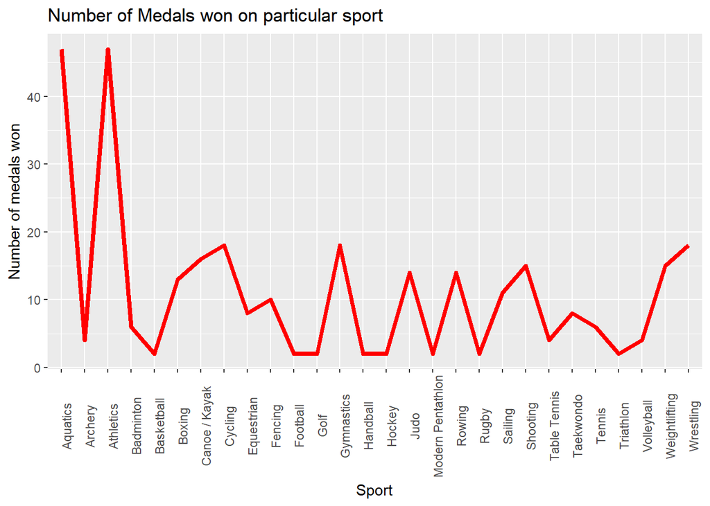

```r
aquatics<-country_lead%>%
  ggplot(aes(y=Popular_sport, x = Sport, group = 1))+
  geom_line(color= "red", size= 1.5)+
  xlab("Sport") +
  ylab("Number of medals won") +
  ggtitle("Number of Medals won on particular sport")+
   theme(axis.text.x = element_text(angle=90, hjust=0.5))
aquatics
```

```r
country_lead%>%
  summarize(med_popular = median(Popular_sport),
            q1_popular = quantile(Popular_sport, 1/4),
            q3_popular = quantile(Popular_sport, 3/4)) %>%
  mutate(d1_depth = med_popular - q1_popular,
         d2_depth = q3_popular - med_popular) %>%
  select(d1_depth, d2_depth)
```

```
## # A tibble: 1 x 2
##   d1_depth d2_depth
##      <dbl>    <dbl>
## 1     6.00     7.00
```

So,from above, we can see that the range of data on one side of the median is longer (or shorter) than the range of data on the other side of the median; therefore, the Popular_sport dataset is skewed.

### Sport’s Popularity based on the top five country with highest Medals

We will use facet grid to represent the total number of medals won by top five countries in the Olympics.

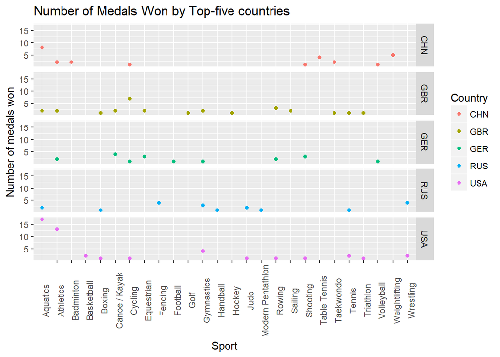

```r
country_lead2 <- olympics_data%>%
  filter(Country %in% c("USA", "GBR","CHN", "RUS", "GER"))%>%
  group_by(Sport, Country)%>%
  summarize(Popular_sport_Count= length(Sport))%>%
  arrange(desc(Popular_sport_Count))%>%
  ggplot(aes(y=Popular_sport_Count, x = Sport))+
  facet_grid(Country~.)+
  geom_point(mapping=aes(color= Country))+
  geom_smooth(method=lm)+
  xlab("Sport") +
  ylab("Number of medals won") +
  ggtitle("Number of Medals Won by Top-five countries")+
  theme(axis.text.x = element_text(angle=90, hjust=0.5))
country_lead2
```

### Top three players in the whole game

```r
players<-have_record%>%
  select(Athlete_Name, Gender)%>%
  group_by(Athlete_Name, Gender)%>%
  summarize(athlete_count = length(Athlete_Name))%>%
  arrange(desc(athlete_count))
players%>%head(3)
```

```
## # A tibble: 3 x 3
## # Groups:   Athlete_Name [3]
##   Athlete_Name    Gender athlete_count
##   <chr>           <chr>          <int>
## 1 Katie Ledecky   W                  2
## 2 Katinka HosszÃº W                  2
## 3 Adam Peaty      M                  1
```

### Categories of aquatics winning highest medals

We will plot the graph by reordering it.Until now, the graphs were not sorted but this plot uses reorder function whilch sorts the graph in descending order.

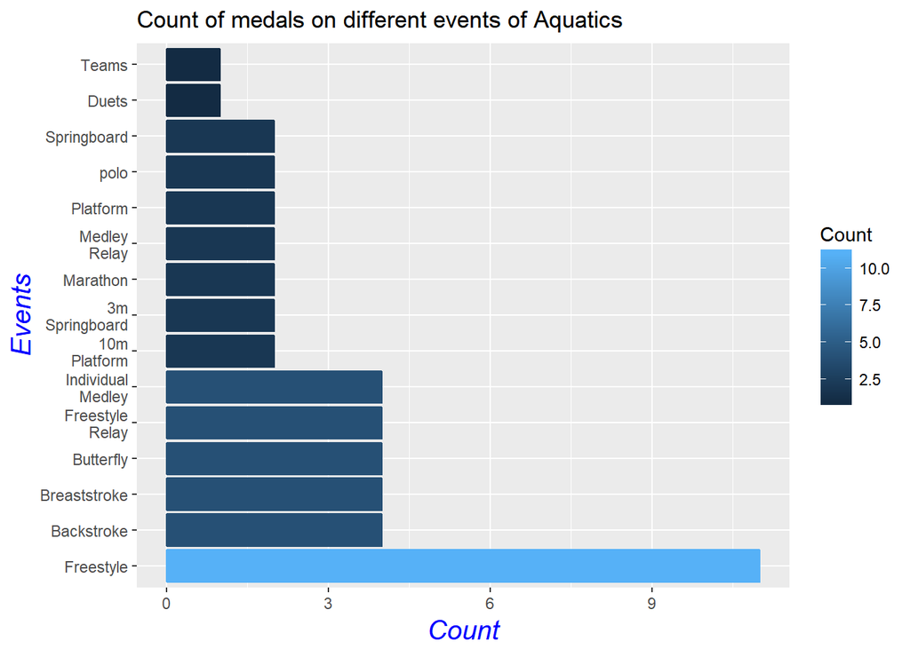

```r
swimming <- olympics_data%>%
  filter(Sport == "Aquatics")%>%
  group_by(Event_name)%>%
  summarize(Count = length(Event_name))

swimming%>%
  ggplot(aes(x = reorder(Event_name, -Count), y = Count)) +
  geom_bar(stat = "identity", mapping = aes(fill= Count, color=Count))+
  scale_x_discrete(labels = function(x) str_wrap(x, width = 5)) +
  theme(axis.title = element_text(face= "italic", color = "blue", size = 15))+
  labs(x = "Events", y = "Count")+
  ggtitle("Count of medals on different events of Aquatics")+
  coord_flip()
```

### Analyzing the count of people having world record(WR) and Olympic Record(OR)

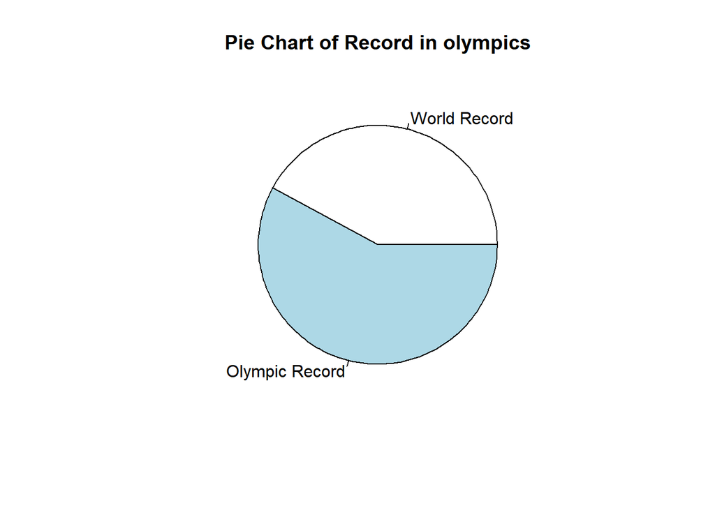

```r
count_OR <- have_record%>%
  group_by(if_OR)%>%
  summarise(or_count = length(if_OR))

lbls <- ifelse(count_OR$if_OR == "Yes", "Olympic Record", "World Record")
pie(count_OR$or_count , labels = lbls, main = "Pie Chart of Record in olympics")
```

The following data is the subset of have_record datframe and gives the total number of Medals won for world record and olympic record. If the if_OR is Yes, it is olympic record, otherwise, it’s world record.

```r
country_record <- have_record%>%
  filter(Country %in% c("USA", "GBR","CHN", "RUS", "GER"))%>%
  group_by(if_OR, Country)%>%
  subset(select= -c(Sport, Records))%>%
  summarise(Yes_Count = length(if_OR))
country_record
```

```
## # A tibble: 8 x 3
## # Groups:   if_OR [?]
##   if_OR Country Yes_Count
##   <chr> <chr>       <int>
## 1 No    CHN             2
## 2 No    GBR             1
## 3 No    USA             3
## 4 Yes   CHN             1
## 5 Yes   GBR             1
## 6 Yes   GER             3
## 7 Yes   RUS             1
## 8 Yes   USA             5
```

### Representation of above data in 3D

This data reveals that among top five countries winning large number of medals, only China, Great Britain and US has people with world record.

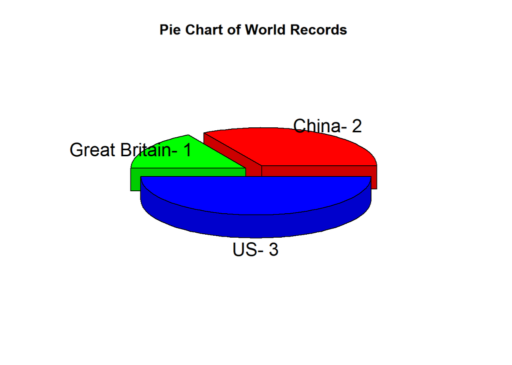

```r
slices <- c(2, 1, 3)
lbl <- c("China- 2", "Great Britain- 1", "US- 3")
pie3D(slices,labels=lbl,explode=0.1,
    main="Pie Chart of World Records ")
```

This data reveals that among top five countries winning large number of medals, only China, Great Britain, Germany Russia and US has people with olympic record.

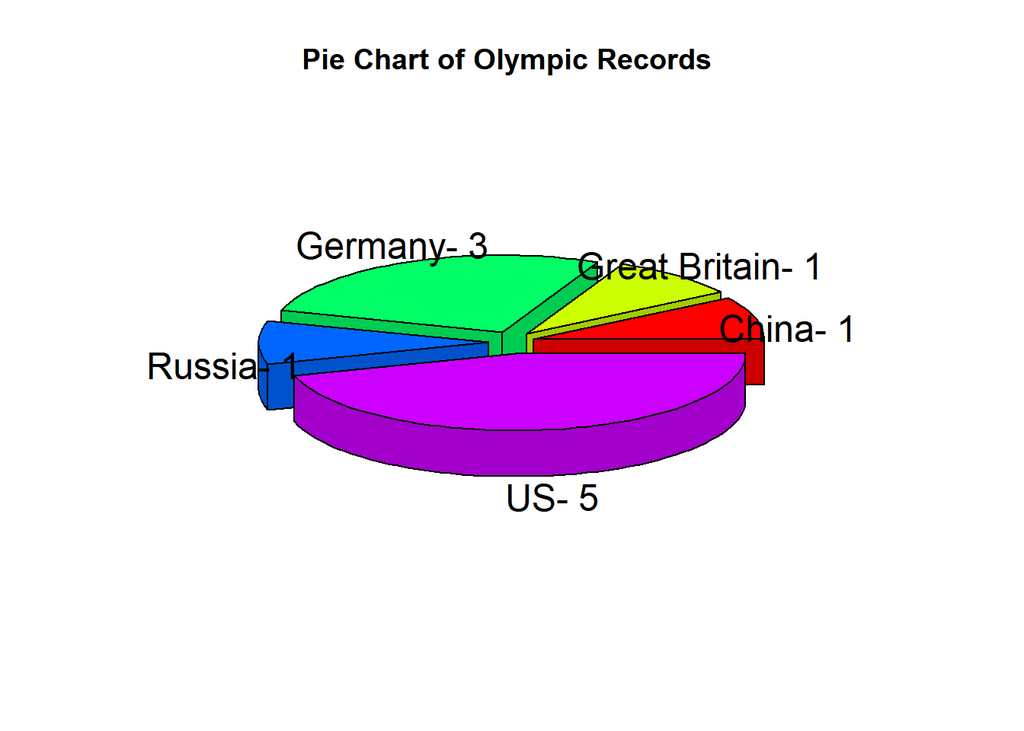

```r
slices_2 <- c(1, 1, 3, 1, 5)
lbl_2 <- c("China- 1", "Great Britain- 1", "Germany- 3" , "Russia- 1", "US- 5")
pie3D(slices_2,labels=lbl_2,explode=0.1,
    main="Pie Chart of Olympic Records ")
```

## Hypothesis Testing and Machine learning

We will be performing a statistical hypothetical testing. Hypothesis testing is, in a way, the formal way of validating the hypothesis claim that is made about a population. Statistical Hypothesis can be classified into into 2 types; null hypothesis and alternative hypothesis.

In simple words, null Hypothesis is the claim that’s on trial is called the null hypothesis. The null hypothesis testing is denoted by H0. Alternative Hypothesis is the one we would believe if the null hypothesis is concluded to be untrue. The evidence in the trial is data and the statistics that go along with it. The alternative hypothesis testing is denoted by H1 or Ha.

The another important term is significance level which basicall means the probability of rejecting the null hypothesis in a statistical test when it is true. Usually 0.05 is taken as the significance level.

### Hypothesis Testing

Through EDA, we are able to find that there is not much Gender differences on winning the medal. The common stereotype is that men are most capable in physical activites and women would lag behind. However, looking at the table above, we don’t see much difference in the mean of Male and Female.It is observed that among the top three players, two of them are women. Therefore we can carry out significance tests using alpha = 0.05. So, the hypothesis for this tutorial is based on the gender differences. The null and alternative hypothesis for this tutorial is stated below:

### Null hypothesis:

Null hypothesis: There is no difference between males and females in terms of winning medals in olympics .It is symbolized as Ho:u1-u2 = 0

### Alternative hypothesis:

Alternative hypotheis: There are differences between males and females in terms of winning medals in olympics. It is symbolized as Ha:u1-u2 != 0.

### t-test statistics

A t-test looks at the t-statistic, the t-distribution and degrees of freedom to determine the probability of difference between variables.

The basic t- test is applied on this tutorial. We will apply t-test and compare two vectors. We will be analyzing data on the basis of sports involved and the gender.We are using significance level of 5%.

The following data gives count for gender which are using in tidying the dataset. Also, we eliminate the X gender because, they fall on the minority category and we can see that there is huge difference between X gender and other genders.

```r
# subset of tidy data with Sport, gender, gender count
tree_data <- olympics_data%>%
  select(Sport, Gender)%>%
  group_by(Sport, Gender)%>%
  summarize(g_count = length(Gender))%>%
  subset(Gender!= "X")
tree_data
```

```
## # A tibble: 54 x 3
## # Groups:   Sport [27]
##    Sport      Gender g_count
##    <chr>      <chr>    <int>
##  1 Aquatics   M           22
##  2 Aquatics   W           25
##  3 Archery    M            2
##  4 Archery    W            2
##  5 Athletics  M           24
##  6 Athletics  W           23
##  7 Badminton  M            2
##  8 Badminton  W            2
##  9 Basketball M            1
## 10 Basketball W            1
## # ... with 44 more rows
```

### Descriptive Statistics

Descriptive statitics are often used to describe basic features of data in a study.They are the basis of virtually every quatitave data. Below, we will see some factors taken in account for descriptive statistics and analysis.

```r
stat_tree <- tree_data%>%
  group_by(Gender)%>%
  summarize(avg_count = mean(g_count), sd_count = sd(g_count))
stat_tree
```

```
## # A tibble: 2 x 3
##   Gender avg_count sd_count
##   <chr>      <dbl>    <dbl>
## 1 M           5.96     6.14
## 2 W           5.07     6.03
```

Given dataset below is filtering the tree_data with two datasets having men and women counterparts separately.

```r
#divide the datset into two Groups
treeM <- tree_data %>%
  filter(Gender == "M")%>%
  group_by(Gender)

treeF <- tree_data %>%
  filter(Gender == "W")%>%
  group_by(Gender)
```

we will now perform a t_test with 95% confidence interval and it is going to be two sided. Confidence interval is the range of values defined such that there is specified probability that the value of parameter lies within.

```r
t.test(treeM$g_count, treeF$g_count, mu = 0, con4f.level = 0.95, alternative = "two.sided", paired = FALSE)
```

```
##
##  Welch Two Sample t-test
##
## data:  treeM$g_count and treeF$g_count
## t = 0.53681, df = 51.985, p-value = 0.5937
## alternative hypothesis: true difference in means is not equal to 0
## 95 percent confidence interval:
##  -2.433878  4.211656
## sample estimates:
## mean of x mean of y
##  5.962963  5.074074
```

The table shows t = 0.53681, with the degree of freedom df = 51.985. The p-value equals 0.5937. With this given p-value and using significance level of 0.05, we fail to reject the null hypothesis and reject the alternative hypothesis saying that there is a difference between the male and the females. Therefore, we cannot conclude that there is a significant difference between the physical qualities and sport involvement of female and male players.

A 95% confidence interval for the difference in mean count is given by

```r
diff <- treeM$g_count - treeF$g_count

t.test(diff)
```

```
##
##  One Sample t-test
##
## data:  diff
## t = 2.1093, df = 26, p-value = 0.0447
## alternative hypothesis: true mean is not equal to 0
## 95 percent confidence interval:
##  0.02266468 1.75511310
## sample estimates:
## mean of x
## 0.8888889
```

Form the above data, the confidence interval is between 0.02 and 1.75. This shows that 95% of the true population mean differences between these two gender are in this intervals.

## Machine learning

### Linear Regression

One of the most used techniques in class is linear regression where we can examine the potential relationship between variable and a set of oe or more variables.In this tutorial, we will examine linear model for gender count.

Following is the plot which gets a violin plot for the count of gender.

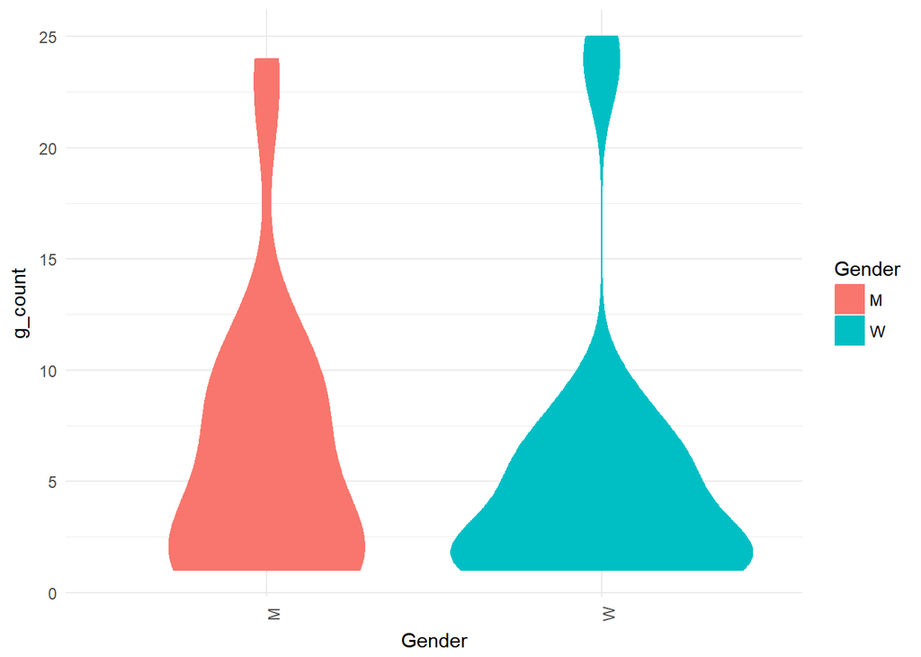

```r
graph_tree<-tree_data %>%
  ggplot(aes(y = g_count, x= Gender)) +
  geom_violin(aes(fill= Gender, color=Gender)) +
  theme_minimal()+
  theme(axis.text.x = element_text(angle=90, hjust=0.5))

graph_tree
```

Following code uses lm function to interpret the data.

```r
library(broom)
tree_fit <- lm(g_count~Gender, data = tree_data, family = binomial)
tree_fit
```

```
##
## Call:
## lm(formula = g_count ~ Gender, data = tree_data, family = binomial)
##
## Coefficients:
## (Intercept)      GenderW
##      5.9630      -0.8889
```

According to this model, when the female is not counted, the total number of men counterparts would be 5.9630. This statement can be verified from the descriptive statistics too. Also note that the units of outcome of Y and the predictor x matter for the values.

```r
tidy_tree_fit <- tree_fit%>%
  tidy()
tidy_tree_fit
```

```
##          term   estimate std.error  statistic      p.value
## 1 (Intercept)  5.9629630  1.170876  5.0927363 4.974849e-06
## 2     GenderW -0.8888889  1.655869 -0.5368112 5.936875e-01
```

```r
augmented_gap <- tree_fit%>%
  augment()

augmented_gap%>% head()
```

```
##   g_count Gender  .fitted  .se.fit    .resid       .hat   .sigma
## 1      22      M 5.962963 1.170876 16.037037 0.03703704 5.701284
## 2      25      W 5.074074 1.170876 19.925926 0.03703704 5.445814
## 3       2      M 5.962963 1.170876 -3.962963 0.03703704 6.117326
## 4       2      W 5.074074 1.170876 -3.074074 0.03703704 6.127728
## 5      24      M 5.962963 1.170876 18.037037 0.03703704 5.578262
## 6      23      W 5.074074 1.170876 17.925926 0.03703704 5.585550
##       .cooksd .std.resid
## 1 0.138755347  2.6861270
## 2 0.214209381  3.3374972
## 3 0.008473084 -0.6637773
## 4 0.005098356 -0.5148927
## 5 0.175522121  3.0211174
## 6 0.173366291  3.0025068
```

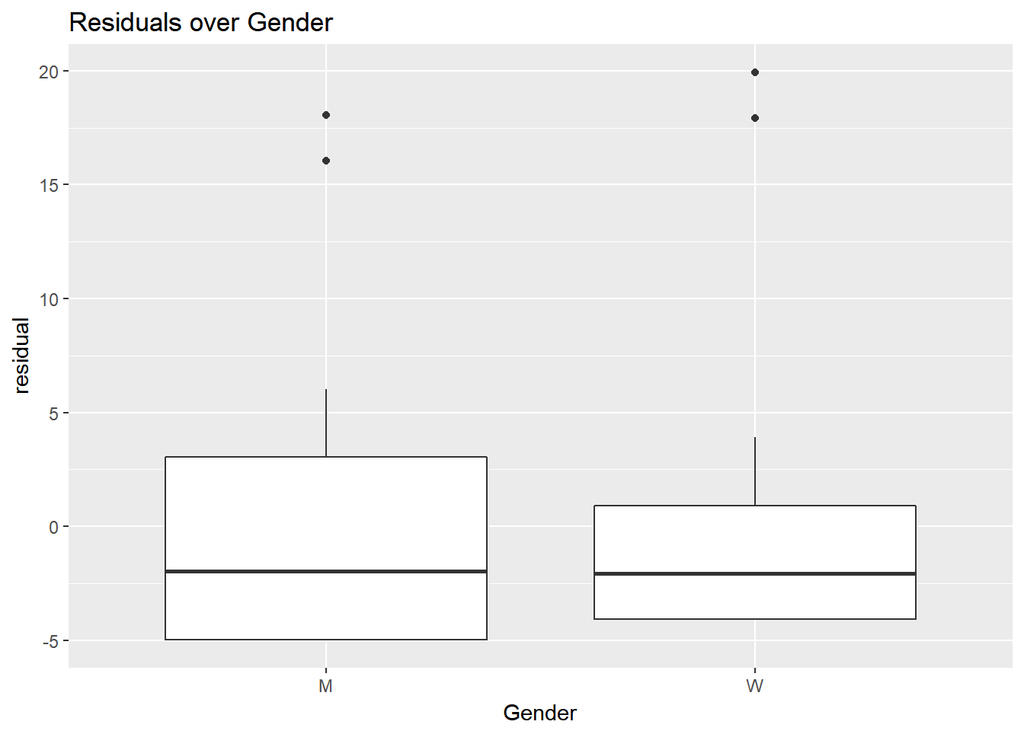

```r
augmented_gap%>%
  ggplot(aes(x=factor(Gender), y=.resid)) +
  geom_boxplot() +
  labs(title="Residuals over Gender", x = "Gender", y = "residual")
```

There seem to be a slight dependence of residuals and Gender as the residuals are less distibuted for women.On the other hand, we can make the plot to check for possible nonlinearity.

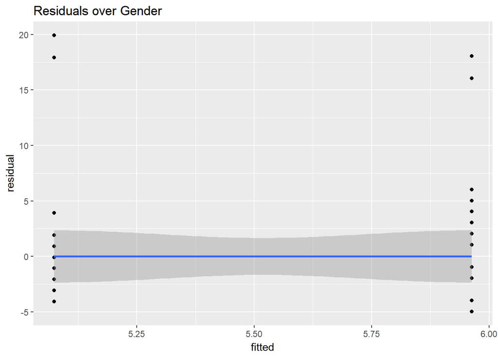

```r
augmented_gap%>%
  ggplot(aes(x=.fitted, y=.resid)) +
  geom_point() +
  geom_smooth(method = loess) +
  labs(title="Residuals over Gender", x = "fitted", y = "residual")
```

We are going to consider another linear regresion model which considers Sport and G_count.

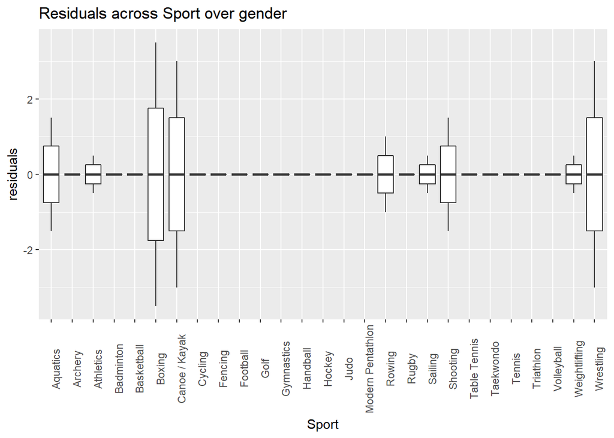

```r
tree_fit_two <- lm(g_count~Sport,data=tree_data)%>%
  augment()
tree_fit_two %>%
  ggplot(aes(x=factor(Sport), y=.resid)) +
  geom_boxplot() +
  labs(title="Residuals across Sport over gender", x = "Sport", y = "residuals")+
  theme(axis.text.x = element_text(angle=90, hjust=0.5))
```

The data distributed is unsymmetric and boxing seem to have high number of residuals.

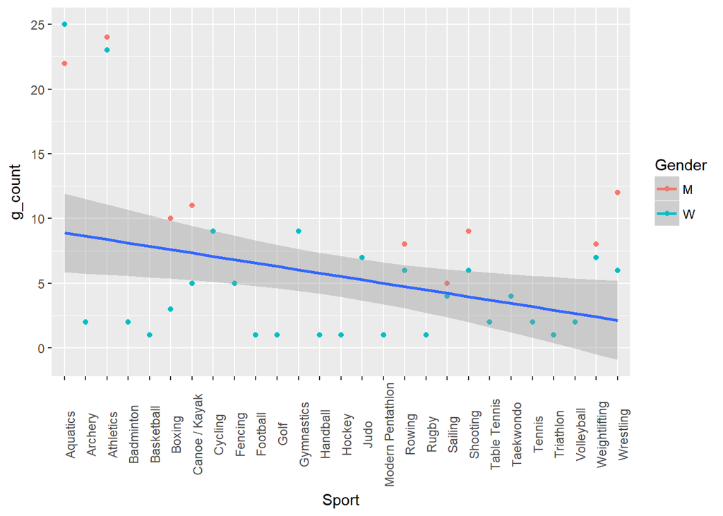

```r
tree_data%>%
  ggplot(aes(y= g_count, x = Sport, color = Gender, group = 1))+
  geom_point()+
  geom_smooth(method = lm) +
  theme(axis.text.x = element_text(angle=90, hjust=0.5))
```

## References:

This tutorial highlighted techniques for data analysis. Much more details about the libraries and the links that helped in this project are as follows:

- Data used:[Click here](https://raw.githubusercontent.com/nbremer/olympicfeathers/gh-pages/data/raw%20medal%20data/Rio%202016%20gold%20medal%20winners.txt)
- Linear Regression:[Ready to learn about linear model](https://www.hackerearth.com/practice/machine-learning/machine-learning-algorithms/beginners-guide-regression-analysis-plot-interpretations/tutorial/)
- EDA: [Let's turn pages from the lecture](http://www.hcbravo.org/IntroDataSci/bookdown-notes/exploratory-data-analysis-visualization.html)
- Newspaper reference:[Guardian.com](https://www.theguardian.com/sport/ng-interactive/2016/aug/05/rio-olympics-2016-medal-table-and-results-in-full)
- Libraries: Click and see
- Image Source: [Medal](http://images.wisegeek.com/olympic-medals.jpg)